# uni_walkthrough

```python
import torch
import torchvision
import os
from os.path import join as j_
from PIL import Image
import pandas as pd
import numpy as np

# loading all packages here to start
from uni import get_encoder
from uni.downstream.extract_patch_features import extract_patch_features_from_dataloader
from uni.downstream.eval_patch_features.linear_probe import eval_linear_probe
from uni.downstream.eval_patch_features.fewshot import eval_knn, eval_fewshot
from uni.downstream.eval_patch_features.protonet import ProtoNet, prototype_topk_vote
from uni.downstream.eval_patch_features.metrics import get_eval_metrics, print_metrics
from uni.downstream.utils import concat_images
device = torch.device("cuda" if torch.cuda.is_available() else "cpu")
```

### Downloading UNI weights + Creating Model

```python
import timm
from timm.data import resolve_data_config
from timm.data.transforms_factory import create_transform
from huggingface_hub import login
from dotenv import load_dotenv
load_dotenv()

login(token=os.environ.get("HF_TOKEN"))  # login with your User Access Token, found at https://huggingface.co/settings/tokens

# init_values need to be passed in to successfully load LayerScale parameters (e.g. - block.0.ls1.gamma)
# pretrained=True needed to load UNI2-h weights (and download weights for the first time)
timm_kwargs = {
            'img_size': 224,
            'patch_size': 14,
            'depth': 24,
            'num_heads': 24,
            'init_values': 1e-5,
            'embed_dim': 1536,
            'mlp_ratio': 2.66667*2,
            'num_classes': 0,
            'no_embed_class': True,
            'mlp_layer': timm.layers.SwiGLUPacked,
            'act_layer': torch.nn.SiLU,
            'reg_tokens': 8,
            'dynamic_img_size': True
        }
model = timm.create_model("hf-hub:MahmoodLab/UNI2-h", pretrained=True, **timm_kwargs)
transform = create_transform(**resolve_data_config(model.pretrained_cfg, model=model))
model.eval()
```

```
Note: Environment variable`HF_TOKEN` is set and is the current active token independently from the token you've just configured.
```

[output not shown]

[output cut: 536 more lines]

[output not shown]

```python
import os
import torch
from torchvision import transforms
import timm
from huggingface_hub import login, hf_hub_download

login(token=os.environ.get("HF_TOKEN"))  # login with your User Access Token, found at https://huggingface.co/settings/tokens

local_dir = "../assets/ckpts/uni2-h/"
os.makedirs(local_dir, exist_ok=True)  # create directory if it does not exist
hf_hub_download("MahmoodLab/UNI2-h", filename="pytorch_model.bin", local_dir=local_dir, force_download=True)
timm_kwargs = {'img_size': 224,
               'patch_size': 14,
               'depth': 24,
               'num_heads': 24,
               'init_values': 1e-5,
               'embed_dim': 1536,
               'mlp_ratio': 2.66667*2,
               'num_classes': 0,
               'no_embed_class': True,
               'mlp_layer': timm.layers.SwiGLUPacked,
               'act_layer': torch.nn.SiLU,
               'reg_tokens': 8,
               'dynamic_img_size': True
              }
model = timm.create_model(**timm_kwargs)
model.load_state_dict(torch.load(os.path.join(local_dir, "pytorch_model.bin"), map_location="cpu"), strict=True)
model.eval()
model.to(device)
transform = transforms.Compose(
    [
        transforms.Resize(224),
        transforms.ToTensor(),
        transforms.Normalize(mean=(0.485, 0.456, 0.406), std=(0.229, 0.224, 0.225)),
    ]
)
transform
```

[output not shown]

The function `get_encoder` performs the commands above, downloading in the checkpoint in the `./assets/ckpts/` relative path of this GitHub repository.

```python
from uni import get_encoder
model, transform = get_encoder(enc_name='uni2-h', device=device)
```

### ROI Feature Extraction

```python
from uni.downstream.extract_patch_features import extract_patch_features_from_dataloader

# get path to example data
dataroot = '../assets/data/tcga_luadlusc'

# create some image folder datasets for train/test and their data laoders
train_dataset = torchvision.datasets.ImageFolder(j_(dataroot, 'train'), transform=transform)
test_dataset = torchvision.datasets.ImageFolder(j_(dataroot, 'test'), transform=transform)
train_dataloader = torch.utils.data.DataLoader(train_dataset, batch_size=4, shuffle=False)
test_dataloader = torch.utils.data.DataLoader(test_dataset, batch_size=4, shuffle=False)

# extract patch features from the train and test datasets (returns dictionary of embeddings and labels)
train_features = extract_patch_features_from_dataloader(model, train_dataloader)
test_features = extract_patch_features_from_dataloader(model, test_dataloader)

# convert these to torch
train_feats = torch.Tensor(train_features['embeddings'])
train_labels = torch.Tensor(train_features['labels']).type(torch.long)
test_feats = torch.Tensor(test_features['embeddings'])
test_labels = torch.Tensor(test_features['labels']).type(torch.long)
```

```python
train_dataset.class_to_idx
```

```
{'LUAD': 0, 'LUSC': 1}
```

```python
dataloader = test_dataloader
```

```python
from tqdm import tqdm
all_embeddings, all_labels = [], []
batch_size = dataloader.batch_size
device = next(model.parameters())[0].device

for batch_idx, (batch, target) in tqdm(
    enumerate(dataloader), total=len(dataloader)
):
    remaining = batch.shape[0]
    if remaining != batch_size:
        _ = torch.zeros((batch_size - remaining,) + batch.shape[1:]).type(
            batch.type()
        )
        batch = torch.vstack([batch, _])

    batch = batch.to(device)
    with torch.inference_mode():
        embeddings = model(batch).detach().cpu()[:remaining, :].cpu()
        labels = target.numpy()[:remaining]
        assert not torch.isnan(embeddings).any()

    all_embeddings.append(embeddings)
    all_labels.append(labels)
```

```python
batch
```

[output not shown]

[output cut: 44 more lines]

[output not shown]

### ROI Linear Probe Evaluation.

```python
from uni.downstream.eval_patch_features.linear_probe import eval_linear_probe

linprobe_eval_metrics, linprobe_dump = eval_linear_probe(
    train_feats = train_feats,
    train_labels = train_labels,
    valid_feats = None ,
    valid_labels = None,
    test_feats = test_feats,
    test_labels = test_labels,
    max_iter = 1000,
    verbose= True,
)

print_metrics(linprobe_eval_metrics)
```

```
Linear Probe Evaluation: Train shape torch.Size([130, 1536])
Linear Probe Evaluation: Test shape torch.Size([60, 1536])
Linear Probe Evaluation (Train Time): Best cost = 30.720
Linear Probe Evaluation (Train Time): Using only train set for evaluation. Train Shape:  torch.Size([130, 1536])
(Before Training) Loss: 0.693
(After Training) Loss: 0.016
Linear Probe Evaluation (Test Time): Test Shape torch.Size([60, 1536])
Linear Probe Evaluation: Time taken 0.84
Test lin_acc: 1.000
Test lin_bacc: 1.000
Test lin_kappa: 1.000
Test lin_weighted_f1: 1.000
Test lin_auroc: 1.000
```

### ROI KNN and ProtoNet evaluation.

```python
from uni.downstream.eval_patch_features.fewshot import eval_knn

knn_eval_metrics, knn_dump, proto_eval_metrics, proto_dump = eval_knn(
    train_feats = train_feats,
    train_labels = train_labels,
    test_feats = test_feats,
    test_labels = test_labels,
    center_feats = True,
    normalize_feats = True,
    n_neighbors = 20
)

print_metrics(knn_eval_metrics)
print_metrics(proto_eval_metrics)
```

```
Test knn20_acc: 1.000
Test knn20_bacc: 1.000
Test knn20_kappa: 1.000
Test knn20_weighted_f1: 1.000
Test proto_acc: 1.000
Test proto_bacc: 1.000
Test proto_kappa: 1.000
Test proto_weighted_f1: 1.000
```

### ROI Few-Shot Evaluation (based on ProtoNet)

```python
from uni.downstream.eval_patch_features.fewshot import eval_fewshot

fewshot_episodes, fewshot_dump = eval_fewshot(
    train_feats = train_feats,
    train_labels = train_labels,
    test_feats = test_feats,
    test_labels = test_labels,
    n_iter = 500, # draw 500 few-shot episodes
    n_way = 2, # use all class examples
    n_shot = 4, # 4 examples per class (as we don't have that many)
    n_query = test_feats.shape[0], # evaluate on all test samples
    center_feats = True,
    normalize_feats = True,
    average_feats = True,
)

# how well we did picking 4 random examples per class
display(fewshot_episodes)

# summary
display(fewshot_dump)
```

|  | Kw4s_acc | Kw4s_bacc | Kw4s_kappa | Kw4s_weighted_f1 |
| --- | --- | --- | --- | --- |
| 0 | 0.916667 | 0.916667 | 0.833333 | 0.916084 |
| 1 | 0.683333 | 0.683333 | 0.366667 | 0.648040 |
| 2 | 1.000000 | 1.000000 | 1.000000 | 1.000000 |
| 3 | 1.000000 | 1.000000 | 1.000000 | 1.000000 |
| 4 | 1.000000 | 1.000000 | 1.000000 | 1.000000 |
| ... | ... | ... | ... | ... |
| 495 | 1.000000 | 1.000000 | 1.000000 | 1.000000 |
| 496 | 1.000000 | 1.000000 | 1.000000 | 1.000000 |
| 497 | 1.000000 | 1.000000 | 1.000000 | 1.000000 |
| 498 | 1.000000 | 1.000000 | 1.000000 | 1.000000 |
| 499 | 1.000000 | 1.000000 | 1.000000 | 1.000000 |

500 rows × 4 columns

```
{'Kw4s_acc_avg': 0.9361333333333334,
 'Kw4s_bacc_avg': 0.9361333333333334,
 'Kw4s_kappa_avg': 0.8722666666666666,
 'Kw4s_weighted_f1_avg': 0.9289430547276676,
 'Kw4s_acc_std': 0.11577791069441998,
 'Kw4s_bacc_std': 0.11577791069441998,
 'Kw4s_kappa_std': 0.23155582138883996,
 'Kw4s_weighted_f1_std': 0.13624201632231203}
```

### A Closer Look at ProtoNet

You can use ProtoNet in a sklearn-like API as well for fitting and predicting models.

```python
from uni.downstream.eval_patch_features.protonet import ProtoNet

# fitting the model
proto_clf = ProtoNet(metric='L2', center_feats=True, normalize_feats=True)
proto_clf.fit(train_feats, train_labels)
print('What our prototypes look like:\n', proto_clf.prototype_embeddings.shape)

# evaluating the model
test_pred = proto_clf.predict(test_feats)
get_eval_metrics(test_labels, test_pred, get_report=False)
```

```
Num features averaged per class prototype:
	Class 0: 70
	Class 1: 60
Applying centering...
Applying normalization...
What our prototypes look like:
 torch.Size([2, 1536])
```

```
{'acc': 1.0, 'bacc': 1.0, 'kappa': 1.0, 'weighted_f1': 1.0}
```

Using `proto_clf._get_topk_queries_inds`, we use the test samples as the query set, and get the top-k queries to each prototype, effectively doing ROI retrieval.

```
label2idx correspondenes {'LUAD': 0, 'LUSC': 1}
Top-k LUAD-like test samples to LUAD prototype
```

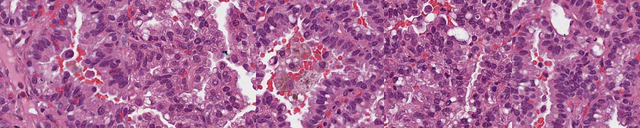

```
Top-k LUSC-like test samples to LUSC prototype
```

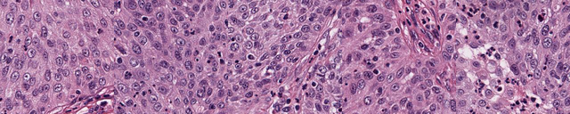

```python
dist, topk_inds = proto_clf._get_topk_queries_inds(test_feats, topk=5)
print('label2idx correspondenes', train_dataset.class_to_idx)
test_imgs_df = pd.DataFrame(test_dataset.imgs, columns=['path', 'label'])

print('Top-k LUAD-like test samples to LUAD prototype')
luad_topk_inds = topk_inds[0]
luad_topk_imgs = concat_images([Image.open(img_fpath) for img_fpath in test_imgs_df['path'][luad_topk_inds]], scale=0.5)
display(luad_topk_imgs)

print('Top-k LUSC-like test samples to LUSC prototype')
lusc_topk_inds = topk_inds[1]
lusc_topk_imgs = concat_images([Image.open(img_fpath) for img_fpath in test_imgs_df['path'][lusc_topk_inds]], scale=0.5)
display(lusc_topk_imgs)
```

```python
test_imgs_df['path'][luad_topk_inds]
```

```
24    ../assets/data/tcga_luadlusc/test/LUAD/2_4_507...
2     ../assets/data/tcga_luadlusc/test/LUAD/0_2_507...
23    ../assets/data/tcga_luadlusc/test/LUAD/2_3_507...
5     ../assets/data/tcga_luadlusc/test/LUAD/0_5_507...
20    ../assets/data/tcga_luadlusc/test/LUAD/2_0_507...
Name: path, dtype: object
```

```python
train_dataset
```

```
Dataset ImageFolder
    Number of datapoints: 130
    Root location: ../assets/data/tcga_luadlusc/train
    StandardTransform
Transform: Compose(
               Resize(size=224, interpolation=bilinear, max_size=None, antialias=True)
               CenterCrop(size=(224, 224))
               ToTensor()
               Normalize(mean=(0.485, 0.456, 0.406), std=(0.229, 0.224, 0.225))
           )
```

Using `proto_clf._get_topk_prototypes_inds`, we can instead use the prototypes as the query set, and get the top-k queries to each test sample. With k set to # of prototypes / labels, we are essentially doing ROI classification (assigning label of the nearest prototype to the test sample).

```python
dist, topk_inds = proto_clf._get_topk_prototypes_inds(test_feats, topk=2)
print("The top-2 closest prototypes to each test sample, with closer prototypes first (left hand side)")
display(topk_inds)

print('Labels of the top-1 closest prototypes')
pred_test = topk_inds[:, 0]
```

```
The top-2 closest prototypes to each test sample, with closer prototypes first (left hand side)
```

```
array([[0, 1],
       [0, 1],
       [0, 1],
       [0, 1],
       [0, 1],
       [0, 1],
       [0, 1],
       [0, 1],
       [0, 1],
       [0, 1],
       [0, 1],
       [0, 1],
       [0, 1],
       [0, 1],
       [0, 1],
```

[output cut: 45 more lines]

```
Labels of the top-1 closest prototypes
```